# Brian Buckley

February 2015

# Descriptive Statistics

```r
# Things to consider:
# How many students did not pass anything
# What is the hardest content to pass
# What is the easiest content to pass
# Remove NA data
# What proportion of content was accessed
# What did Knewton recommend
```

```r
library(googleVis)
op<-options(gvis.plot.tag='chart')
```

```r
str(dataAll)
```

```
## 'data.frame':    1698435 obs. of  13 variables:
##  $ studentId             : chr  "ba4d898e-cbbd-4ed8-a25b-f4d286c6b372" "ba4d898e-cbbd-4ed8-a25b-f4d286c6b372" "ba4d898e-cbbd-4ed8-a25b-f4d286c6b372" "ba4d898e-cbbd-4ed8-a25b-f4d286c6b372" ...
##  $ learningInstance      : chr  "9a3673be-18a4-4510-9243-6ec1fc7187ca" "9a3673be-18a4-4510-9243-6ec1fc7187ca" "9a3673be-18a4-4510-9243-6ec1fc7187ca" "9a3673be-18a4-4510-9243-6ec1fc7187ca" ...
##  $ knowledgeGraph        : chr  "1fc23f3a-efef-4230-8b58-56df5024fb07" "1fc23f3a-efef-4230-8b58-56df5024fb07" "1fc23f3a-efef-4230-8b58-56df5024fb07" "1fc23f3a-efef-4230-8b58-56df5024fb07" ...
##  $ isCorrect             : chr  "Yes" "Yes" "Yes" "Yes" ...
##  $ isComplete            : chr  "Yes" "Yes" "Yes" "Yes" ...
##  $ numberAttempts        : int  1 1 2 4 1 1 2 1 1 2 ...
##  $ timeOnItem            : num  98.7 108.7 NA 107.4 62.1 ...
##  $ contentId             : chr  "cama15g8.20.4.12" "cama15g8.20.4.14" "cama15g8.20.4.18" "cama15g8.20.4.26" ...
##  $ itemScore             : num  1 1 1 1 1 1 1 1 1 1 ...
##  $ interactionEndTime    : chr  "2014-11-04 17:48:20" "2014-11-04 17:50:06" "2014-11-04 17:52:05" "2014-11-04 17:56:39" ...
##  $ receivedRecommendation: chr  "FALSE" "FALSE" "FALSE" "FALSE" ...
##  $ knewtonModuleId       : chr  NA NA NA NA ...
##  $ adaptiveType          : num  0 0 0 0 0 0 0 0 0 0 ...
```

There are **1698435** Observations (rows) Note that character data is a character vector - we will need to convert these to R factors. Also the binary data (*isComplete*, *isCorrect*) are strings rather than a logical value so again these have to be converted.

Now we can get summary statistics for the data

```r
summary(dataAll)
```

```
##   studentId         learningInstance   knowledgeGraph
##  Length:1698435     Length:1698435     Length:1698435
##  Class :character   Class :character   Class :character
##  Mode  :character   Mode  :character   Mode  :character
##
##
##
##
##   isCorrect          isComplete        numberAttempts     timeOnItem
##  Length:1698435     Length:1698435     Min.   :  0.00   Min.   : 60.0
##  Class :character   Class :character   1st Qu.:  1.00   1st Qu.: 85.6
##  Mode  :character   Mode  :character   Median :  1.00   Median :125.9
##                                        Mean   :  1.31   Mean   :169.1
##                                        3rd Qu.:  1.00   3rd Qu.:212.6
##                                        Max.   :138.00   Max.   :600.0
##                                        NA's   :207291   NA's   :1029770
##   contentId           itemScore      interactionEndTime
##  Length:1698435     Min.   :0.00     Length:1698435
##  Class :character   1st Qu.:0.14     Class :character
##  Mode  :character   Median :1.00     Mode  :character
##                     Mean   :0.71
##                     3rd Qu.:1.00
##                     Max.   :1.00
##                     NA's   :207291
##  receivedRecommendation knewtonModuleId     adaptiveType
##  Length:1698435         Length:1698435     Min.   :0.0000
##  Class :character       Class :character   1st Qu.:0.0000
##  Mode  :character       Mode  :character   Median :0.0000
##                                            Mean   :0.1835
##                                            3rd Qu.:0.0000
##                                            Max.   :3.0000
##
```

The character vector variables cannot be statistically summarized. When we convert these to factors later we will be able to perform statistics on them.

## Students in each learningInstance i.e. class

```r
library(plyr)
classes <- count(dataAll, vars = c("studentId", "learningInstance"))
classTotals <- aggregate(freq ~ learningInstance, data = classes, sum)
classTotals <- classTotals[with(classTotals, order(-freq)), ]
summary(classTotals$freq)
```

```
##    Min. 1st Qu.  Median    Mean 3rd Qu.    Max.
##     1.0    32.0   126.0   316.8   372.0  9767.0
```

Note that we have classes with **thousands** of students and with just **one** student. Are these QA data?? Classes with 32 or less students make up just the first quartile of the data.

## Histogram of class size distribution

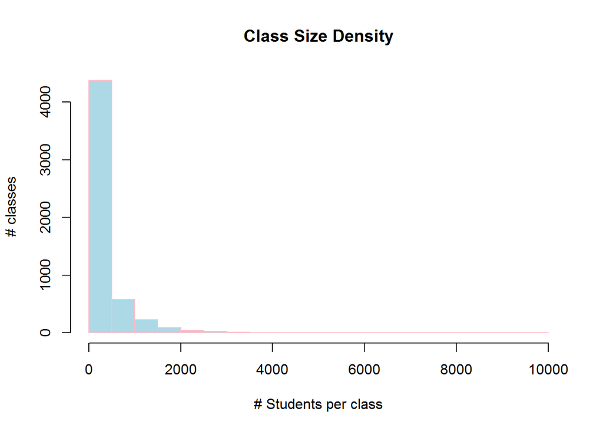

```r
hist(classTotals$freq, col = "lightblue", border = "pink", xlab = "# Students per class",
    ylab = "# classes", main = "Class Size Density")
```

Very skewed-to-the-right data! Looks like we have QA data here?

Let’s take the first quartile class size (32 students) and accept data with 10 or more. Then plot it on a Google Visualizations histogram.

## Plot Google Visualization Chart of the first Quartile

```r
q1classes<-subset(classTotals, freq <= 32 & freq >= 10)
orderedQ1Classes<-q1classes[with(q1classes, order(-freq)),]
hist<-gvisHistogram(orderedQ1Classes, options=list(width=1000,
                                                  height=600,
                                                  title='Class Size Density',
                                                  orientation='vertical'))
plot(hist)
```

The item number when you move the mouse pointer over each bar is the number of individual classes that have the number of students on the y-axis. In this subset we have reduced the number of classes from **5361** to **1102** that appear to be ‘real’ classes rather than QA data.

## Knowledge Graphs

```r
KGs <- count(dataAll$studentId, "dataAll$knowledgeGraph")
orderedKGs <- KGs[with(KGs, order(-freq)), ]
orderedKGs
```

```
##                  dataAll.knowledgeGraph   freq
## 3  40764abd-b944-4092-8ac3-5ab86d0add35 466571
## 10 cefe5933-fb6d-4151-9df0-8662ae9aeb89 310122
## 2  1fc23f3a-efef-4230-8b58-56df5024fb07 235771
## 5  7eda0466-0dab-4ba5-af3c-128fd39bc9fa 179677
## 1  157ac5a7-86f0-4029-afc4-008a78c71be6 174432
## 4  66e121ad-1e83-44c7-82c9-3ac1b79fa584 148926
## 7  9c0f1900-5851-464f-9cb3-708c1c0e946d 135118
## 9  a7f0b328-e184-4d23-bda0-8cd7f10c2193  34617
## 8  9c2322ac-8e4b-4f44-b803-d0a4f9bd3a71   7473
## 6  95fd703e-5088-4dc6-b010-c46e64570f6b   5467
## 11 d2394fe3-fb85-4bda-a637-50459c976210    261
```

```r
bar<-gvisBarChart(orderedKGs, options=list(width=800,
                                            height=600,
                                            title='Knowledge Graph Density',
                                            orientation='vertical'))
plot(bar)
```

There are **11** Knowledge Graphs referenced in the message data but we only have two. This will limit our ability to merge enriched data from the KGs into the message data.

## Total number of unique students and unique content in these data

```r
totStudents <- length(unique(dataAll$studentId))
totContent <- length(unique(dataAll$contentId))
```

There are **56362** unique students and **32875** unique content objects in the raw data.

```r
passed <- subset(dataAll, dataAll$isCorrect == "Yes")
numStudentPassed <- length(unique(passed$studentId))
```

There are **53806** data sessions with passes for the assessments.

Now let’s see how many of these received Knewton recommendations.

```r
recsReceived <- length(unique(subset(passed, receivedRecommendation == "TRUE")$studentId))
```

**6868** student sessions received Knewton recommendations. We will break this down into the different recommendation type later.

Now let’s remove the empty NA data - **note: why are there empty entries here - is this a bug in Adaptive Service?**

```r
passedTimeNa <- na.omit(passed$timeOnItem)
passedAttemptsNa <- na.omit(passed$numberAttempts)
```

Now we will look at the student sessions with failed assessments.

```r
failed <- subset(dataAll, dataAll$isCorrect == "No")
numStudentFailed <- length(unique(failed$studentId))
```

```r
failedTimeNa <- na.omit(failed$timeOnItem)
failedAttemptsNa <- na.omit(failed$numberAttempts)
```

There are **47656** data sessions with failed assessments. We can do some summary statistics to see more detail.

```r
summary(failed)
```

```
##   studentId         learningInstance   knowledgeGraph
##  Length:623655      Length:623655      Length:623655
##  Class :character   Class :character   Class :character
##  Mode  :character   Mode  :character   Mode  :character
##
##
##
##
##   isCorrect          isComplete        numberAttempts     timeOnItem
##  Length:623655      Length:623655      Min.   :  0.00   Min.   : 60.0
##  Class :character   Class :character   1st Qu.:  1.00   1st Qu.: 89.4
##  Mode  :character   Mode  :character   Median :  1.00   Median :134.8
##                                        Mean   :  0.98   Mean   :177.0
##                                        3rd Qu.:  1.00   3rd Qu.:226.4
##                                        Max.   :102.00   Max.   :600.0
##                                        NA's   :121565   NA's   :388903
##   contentId           itemScore      interactionEndTime
##  Length:623655      Min.   :0.00     Length:623655
##  Class :character   1st Qu.:0.00     Class :character
##  Mode  :character   Median :0.00     Mode  :character
##                     Mean   :0.13
##                     3rd Qu.:0.20
##                     Max.   :0.97
##                     NA's   :121565
##  receivedRecommendation knewtonModuleId     adaptiveType
##  Length:623655          Length:623655      Min.   :0.0000
##  Class :character       Class :character   1st Qu.:0.0000
##  Mode  :character       Mode  :character   Median :0.0000
##                                            Mean   :0.2958
##                                            3rd Qu.:0.0000
##                                            Max.   :3.0000
##
```

```r
summary(failed$timeOnItem)
```

```
##    Min. 1st Qu.  Median    Mean 3rd Qu.    Max.    NA's
##    60.0    89.4   134.8   177.0   226.4   600.0  388903
```

```r
summary(failed$numberAttempts)
```

```
##    Min. 1st Qu.  Median    Mean 3rd Qu.    Max.    NA's
##    0.00    1.00    1.00    0.98    1.00  102.00  121565
```

How many of these received Knewton recommendations?

```r
recsReceived <- length(unique(subset(failed, receivedRecommendation == "TRUE")$studentId))
```

**7168** student sessions with failed assessments received Knewton recommendations.

## simple proportion of students who passed against students who failed

```r
studentPieSummary<-data.frame(c('# Passed', '# Failed'), c(numStudentPassed, numStudentFailed))
ss<-gvisPieChart(studentPieSummary, options=list(title='Comparison of Students who passed/failed', width=800, height=800))
plot(ss)
```

We see slightly more than half of the unique student identities passes assessments. Note that this data has not yet been normalized so we will have a number of student ids who passed also appearing in the failed area and vice-versa.

## Comparison of time spent on-task between students who passed and students who failed assessments

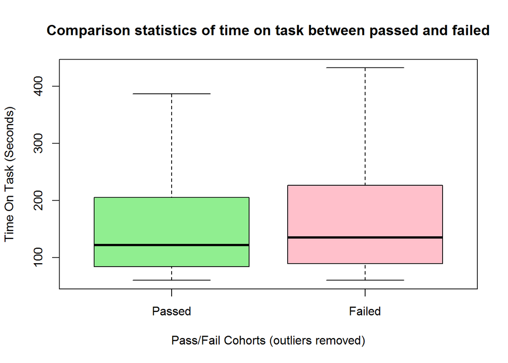

```r
boxplot(passed$timeOnItem, failed$timeOnItem, col = c("lightgreen", "pink"),
    main = "Comparison statistics of time on task between passed and failed",
    xlab = "Pass/Fail Cohorts (outliers removed)", ylab = "Time On Task (Seconds)",
    names = c("Passed", "Failed"), outline = FALSE)
```

There is a narrower spread of time spent on-task from the cohort of students who passed assessments and the median time spent on-task is also lower. Both cohorts show skewness in the longer time-on-task direction. Note that there are a high number of outliers above the top whisker - it might be useful to investigate these particular students to understand why they are taking so long on the learning session. Because we only have anonymized data we did not perform this analysis and removed outliers from the chart for clarity of the overall statistical picture.

## Recommendation adaptive types

```r
recs <- subset(dataAll, receivedRecommendation == "TRUE", select = c(studentId,
    contentId, adaptiveType))
idx <- sapply(recs, is.character)
recs[idx] <- lapply(recs[idx], factor)
```

The adaptive type data is coded as a numerical factor with three levels (1, 2 and 3). We need to convert adaptiveType to a string factor of three more meaningful levels (*warmup*, *intervention* and *enrichment*).

```r
recs$adaptiveType<-factor(recs$adaptiveType)
levels(recs$adaptiveType)<-c("warmup", "intervention", "enrichment")

x<-summary(recs$adaptiveType)
y<-data.frame(names(x), x)
pieC<-gvisPieChart(y, options=list(width=800, height=800, title="Distribution of Adaptive Recommendation types in the data"))
plot(pieC)
```

There seem to be a large proportion of **intervention** recommendations compared with **enrichment** recommendations. This would appear to be as expected given the large proportion of students who failed assessments.

## Merge the content module information into the message data

We can enrich the message data with the categorical information contained in the Knowledge Graph data. let’s merge in the content names and descriptions that match with the content identity carried within the message session data.

```r
mdata <- merge(x = modules, y = dataAll, by.x = "partner_module_id", by.y = "contentId")

summary(mdata)
```

```
##            partner_module_id
##  k6cagm15g3.40.12.21:   839
##  k6cagm15g5.30.14.13:   697
##  k6cagm15g5.30.14.15:   691
##  k6cagm15g5.30.14.25:   679
##  k6cagm15g5.30.14.1 :   670
##  k6cagm15g5.30.14.2 :   667
##  (Other)            :587149
##                             knewton_module_id
##  bafd1cd0-1e41-4078-863d-28fb08f3a038:   839
##  d0494fb1-b198-43c8-964a-94d1df88d74f:   697
##  c4425084-904d-4013-9fbc-3e893e02a924:   691
##  eb68a4fd-08ad-456e-a681-38bb126051a3:   679
##  bbf3c023-b700-4be3-84ae-00ed7d2e5763:   670
##  faec11c9-8086-4402-92ba-f8a64a4b6e7e:   667
##  (Other)                             :587149
##                                         module_name      BLANK
##  CA Grade 3 Chapter 4 Chapter Review Ex. 17a-d:   839   Mode:logical
##  CA Grade 5 Chapter 3 Chapter Review Ex. 11   :   697   NA's:591392
##  CA Grade 5 Chapter 3 Chapter Review Ex. 13a-c:   691
##  CA Grade 5 Chapter 3 Chapter Review Ex. 21   :   679
##  CA Grade 5 Chapter 3 Chapter Review Ex. 1    :   670
##  CA Grade 5 Chapter 3 Chapter Review Ex. 2a-c :   667
##  (Other)                                      :587149
##   scorable       taxon_recommendable BLANK.1
##  Mode :logical   Mode :logical       Mode:logical
##  FALSE:591392    FALSE:5520          NA's:591392
##  NA's :0         TRUE :585872
##                  NA's :0
##
##
##
##                              Standard1
##  California Common Core: 5|NBT|2|7: 64548
##  California Common Core: 3|OA|1|3 : 25905
##  California Common Core: 4|NBT|2|5: 22894
##  California Common Core: 5|NBT|2|6: 19602
##  California Common Core: 4|NBT|2|6: 16586
##  California Common Core: 8|F|4    : 11329
##  (Other)                          :430528
```

[output cut: 33 more lines]

```
##  Min.   :0.0000   Length:591392      Length:591392
##  1st Qu.:0.1700   Class :character   Class :character
##  Median :1.0000   Mode  :character   Mode  :character
##  Mean   :0.7103
##  3rd Qu.:1.0000
##  Max.   :1.0000
##
##  knewtonModuleId     adaptiveType
##  Length:591392      Min.   :0
##  Class :character   1st Qu.:0
##  Mode  :character   Median :0
##                     Mean   :0
##                     3rd Qu.:0
##                     Max.   :0
##
```

## Compare DOK with actual outcomes

The DOK stands for ‘**Depth Of Knowledge**’ required. It is therefore a measure of learning difficulty for a particular content object.

This analysis aims to compare the DOK distribution and see if the actual student outcomes in terms of pass/fail matches the expected DOK distribution. A pie-chart is a good visual way to display this.

```r
failDOK <- subset(failed, select = c(DOK))
passDOK <- subset(passed, select = c(DOK))
totalDOK <- subset(mdata, !is.na(mdata$timeOnItem), select = c(DOK))
```

Comparative pie plots

```r
x1<-summary(totalDOK$DOK)
y1<-data.frame(names(x1), x1)
y1<-subset(y1, x1>0)
title<-paste('DOK distribution for all Content in the data (', sum(y1$x1), ' items)', sep=' ')
dokT<-gvisPieChart(y1, options=list(title=title, width=500, height=500))

x2<-summary(passDOK$DOK)
y2<-data.frame(names(x2), x2)
y2<-subset(y2, x2>0)
title<-paste('DOK disribution for Content Passed (', sum(y2$x2), ' items)', sep=' ')
dokP<-gvisPieChart(y2, options=list(title=title, width=500, height=500))

x3<-summary(failDOK$DOK)
y3<-data.frame(names(x3), x3)
y3<-subset(y3, x3>0)
title<-paste('DOK distribution for Content Failed (', sum(y3$x3), ' items)', sep=' ')
dokF<-gvisPieChart(y3, options=list(title=title, width=500, height=500))

plot(gvisMerge(dokT, dokP, horizontal=TRUE))
```

The distribution of content passed seems very close to the total DOK distribution so it appears the DOK levels are appropriate based on student outcome for those students passing the assessments. But in the distribution of content failed the student outcomes suggest that the **DOK level 3** content might be more difficult than the DOK level would assume.

**Comparative bar plot**

This is the same information above but in a single bar plot.

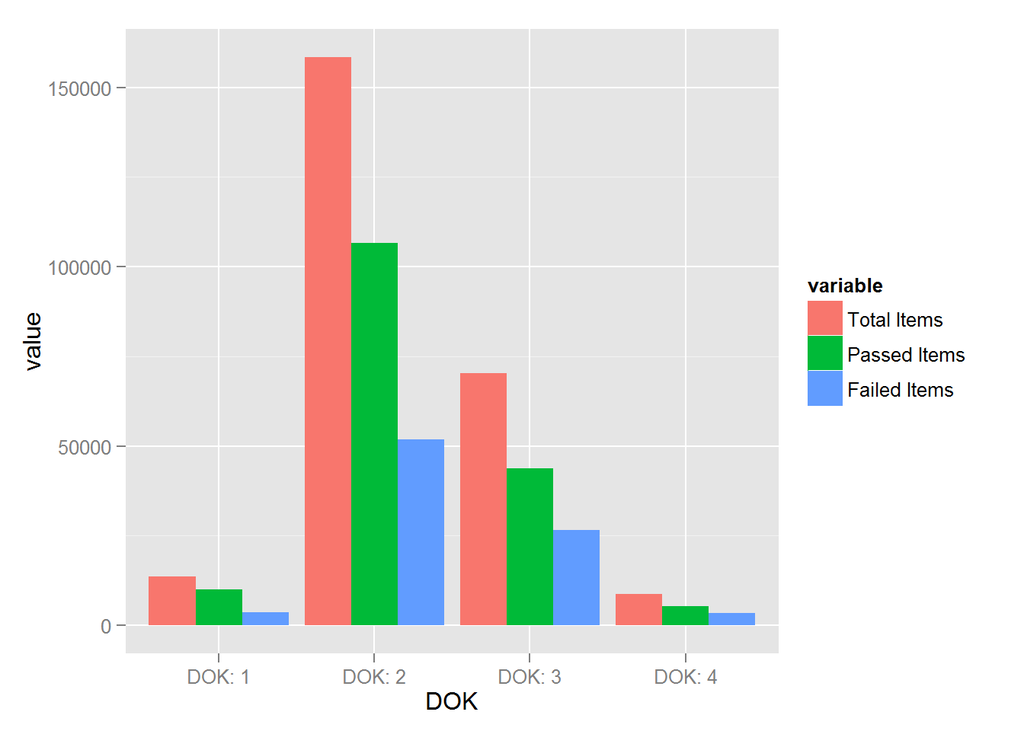

```r
yAll <- as.data.frame(cbind(y1$x1, y2$x2, y3$x3))
yAll <- cbind(yAll, y1$names.x1)
colnames(yAll) = c("V2", "V3", "V4", "V1")
yAll <- subset(yAll, select = c(V1, V2:V4))
colnames(yAll) = c("DOK", "Total Items", "Passed Items", "Failed Items")

library(ggplot2)
library(reshape2)
ylong <- melt(yAll)
ggplot(ylong, aes(DOK, value, fill = variable)) + geom_bar(stat = "identity",
    position = "dodge")
```

The Pie Chart comparison appears to be easier to interpret in this case.

## Aggregate class pass/fail statistics between classes

```r
x <- subset(mdata, select = c(learningInstance, isCorrect))
idx <- sapply(x, is.character)
x[idx] <- lapply(x[idx], factor)
levels(x$learningInstance) <- c(1:length(x$learningInstance))
levels(x$isCorrect) <- c(1, 2)

summary(x)
```

```
##  learningInstance isCorrect
##  1146   :  5393   1:195604
##  1113   :  5101   2:395788
##  480    :  5042
##  1457   :  4690
##  547    :  4649
##  1326   :  4005
##  (Other):562512
```

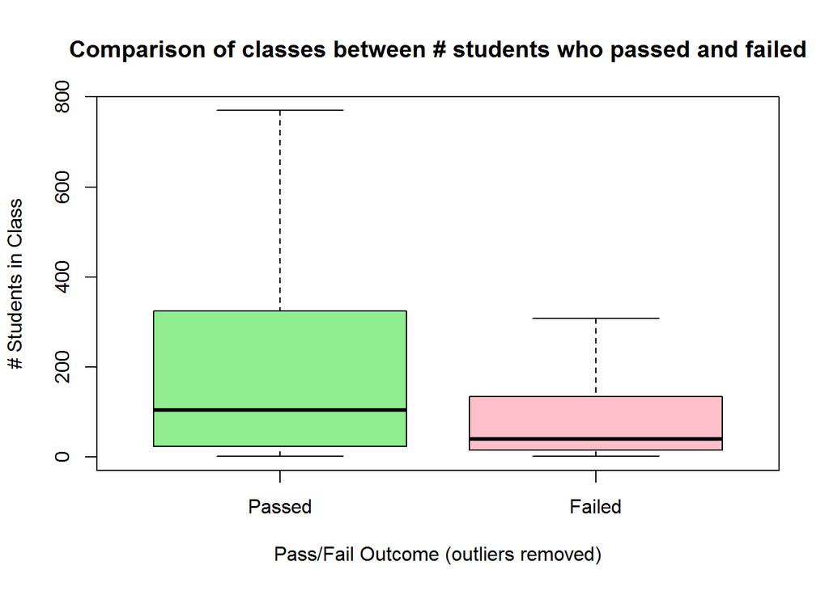

```r
idx <- sapply(x, is.factor)
x[idx] <- lapply(x[idx], as.integer)

classes <- unique(x$learningInstance)
class <- integer(length(x[[1]]))
passed <- integer(length(x[[1]]))
failed <- integer(length(x[[1]]))
count <- 1
for (i in 1:length(classes)) {
    tmp <- subset(x, learningInstance == classes[i])
    for (j in 1:length(tmp[[1]])) {
        class[count] <- tmp[j, ]$learningInstance
        if (tmp[j, ]$isCorrect == 1) {
            failed[count] <- 1
            passed[count] <- NA
        } else {
            passed[count] <- 1
            failed[count] <- NA
        }
        count = count + 1
    }
}
classesComp <- data.frame(class, passed, failed)

aggregatedPass <- aggregate(passed ~ class, FUN = sum, data = classesComp)
aggregatedFail <- aggregate(failed ~ class, FUN = sum, data = classesComp)

aggregatedPass$outcome <- "passed"
aggregatedFail$outcome <- "failed"

dataAllAggregated <- rbind.fill(aggregatedPass, aggregatedFail)

dupRows <- dupsBetweenGroups(dataAllAggregated, "outcome")

# Now separate out unique students in passed and failed categories
dataAllAggOutcome <- cbind(dataAllAggregated, unique = !dupRows)
dataAllAggOutcomePass <- subset(dataAllAggOutcome, outcome == "passed" & unique ==
    TRUE)
dataAllAggOutcomeFail <- subset(dataAllAggOutcome, outcome == "failed" & unique ==
    TRUE)

# Get rid of temporary data
dataAllAggOutcomeFail$passed <- NULL
dataAllAggOutcomeFail$outcome <- NULL
dataAllAggOutcomeFail$unique <- NULL
dataAllAggOutcomePass$failed <- NULL
dataAllAggOutcomePass$outcome <- NULL
dataAllAggOutcomePass$unique <- NULL

# order the results
PassOrdered <- dataAllAggOutcomePass[with(dataAllAggOutcomePass, order(-passed)),
    ]
FailOrdered <- dataAllAggOutcomeFail[with(dataAllAggOutcomeFail, order(-failed)),
    ]

boxplot(PassOrdered$passed, FailOrdered$failed, col = c("lightgreen", "pink"),
    main = "Comparison of classes between # students who passed and failed",
    xlab = "Pass/Fail Outcome (outliers removed)", ylab = "# Students in Class",
    names = c("Passed", "Failed"), outline = FALSE)
```

This data indicates failing classes have fewer students than passing classes. However, this data has not had the apparently QA data (very large class sizes) removed so no real conclusions can be drawn at this stage. The large class filtered analysis will be done at a later time.